# Homework 5

#### 6. Briefly explain how shrinkage methods work (variance-bias tradeoff).

Shrinkage methods shrink the coefficients in the model towards zero. In OLS, the coefficients are unbiased but don’t have the lowest variance due to inflation from multicollinearity. Shrinkage introduces bias to these coefficients as a way to lower the variance. This is the variance-bias tradeoff, where you can greatly reduce variance at the cost of a small increase in bias. This allows for getting around the multicollinearity problem.

#### 7. Briefly explain the similarities/difference between ridge regression, LASSO, and elastic net.

One big difference for ridge regression vs the other shrinkage methods is that it keeps all variables in the model. We can still address multicollinearity, but you might want to keep all predictors in the model. LASSO is a variable selection method that allows you to shrink estimates all the way to zero. It performs worse than ridge regression when there is high multicollinearity and also has more bias and a potential to miss out on variable effects. Elastic net is the best shrinkage method, overcoming any limitations from both ridge and LASSO methods.

#### 8. Remember, when coding these methods, the response variable must be the last column in the data set for the `bestglm` function to work. Switch the order of the columns in the data set so that brozek is last.

```r
bodyfat <- bodyfat %>%
  relocate(brozek, .after = abdom)
```

#### 9. Apply the best subsets variable selection procedure to this data set. You may choose which metric you would like to use (ex: AIC, BIC, PMSE). Output a summary of the “best” model.

```r
best_subsets <- bestglm(bodyfat,
                        IC = "CV",
                        method = "exhaustive")

#best glm uses last column in dataset as response variable

# view variables included in the top 10 models
#best_subsets$BestModels

# view a summary of the "best" model
summary(best_subsets$BestModel)
```

```
##
## Call:
## lm(formula = y ~ ., data = data.frame(Xy[, c(bestset[-1], FALSE),
##     drop = FALSE], y = y))
##
## Residuals:
##      Min       1Q   Median       3Q      Max
## -10.0656  -2.9685  -0.1073   3.0258   9.9220
##
## Coefficients:
##              Estimate Std. Error t value Pr(>|t|)
## (Intercept) -42.87040    2.45735 -17.446  < 2e-16 ***
## weight       -0.12206    0.01966  -6.207 2.26e-09 ***
## abdom         0.90426    0.05221  17.321  < 2e-16 ***
## ---
## Signif. codes:  0 '***' 0.001 '**' 0.01 '*' 0.05 '.' 0.1 ' ' 1
##
## Residual standard error: 4.074 on 247 degrees of freedom
## Multiple R-squared:  0.7212, Adjusted R-squared:  0.7189
## F-statistic: 319.4 on 2 and 247 DF,  p-value: < 2.2e-16
```

#### 10. Apply the forward selection procedure to this data set. You may choose which metric you would like to use (ex: AIC, BIC, PMSE). Output a summary of the “best” model.

```r
forward <- bestglm(bodyfat,
                       IC = "CV",
                       method = "forward")

summary(forward$BestModel)
```

```
##
## Call:
## lm(formula = y ~ ., data = data.frame(Xy[, c(bestset[-1], FALSE),
##     drop = FALSE], y = y))
##
## Residuals:
##      Min       1Q   Median       3Q      Max
## -10.0656  -2.9685  -0.1073   3.0258   9.9220
##
## Coefficients:
##              Estimate Std. Error t value Pr(>|t|)
## (Intercept) -42.87040    2.45735 -17.446  < 2e-16 ***
## weight       -0.12206    0.01966  -6.207 2.26e-09 ***
## abdom         0.90426    0.05221  17.321  < 2e-16 ***
## ---
## Signif. codes:  0 '***' 0.001 '**' 0.01 '*' 0.05 '.' 0.1 ' ' 1
##
## Residual standard error: 4.074 on 247 degrees of freedom
## Multiple R-squared:  0.7212, Adjusted R-squared:  0.7189
## F-statistic: 319.4 on 2 and 247 DF,  p-value: < 2.2e-16
```

#### 11. Apply the backward selection procedure to this data set. You may choose which metric you would like to use (ex: AIC, BIC, PMSE). Output a summary of the “best” model.

```r
backward <- bestglm(bodyfat,
                       IC = "CV",
                       method = "backward")

summary(backward$BestModel)
```

```
##
## Call:
## lm(formula = y ~ ., data = data.frame(Xy[, c(bestset[-1], FALSE),
##     drop = FALSE], y = y))
##
## Residuals:
##     Min      1Q  Median      3Q     Max
## -8.7685 -3.0213 -0.0948  3.0441 10.1815
##
## Coefficients:
##             Estimate Std. Error t value Pr(>|t|)
## (Intercept)  5.07086    7.25124   0.699 0.485019
## height      -0.45346    0.10443  -4.342 2.06e-05 ***
## neck        -0.59792    0.16885  -3.541 0.000477 ***
## abdom        0.74045    0.03646  20.307  < 2e-16 ***
## ---
## Signif. codes:  0 '***' 0.001 '**' 0.01 '*' 0.05 '.' 0.1 ' ' 1
##
## Residual standard error: 4.046 on 246 degrees of freedom
## Multiple R-squared:  0.7261, Adjusted R-squared:  0.7228
## F-statistic: 217.4 on 3 and 246 DF,  p-value: < 2.2e-16
```

#### 12. Apply the sequential replacement selection procedure to this data set. You may choose which metric you would like to use (ex: AIC, BIC, PMSE). Output a summary of the “best” model.

```r
stepwise <- bestglm(bodyfat,
                       IC = "CV",
                       method = "seqrep")

summary(stepwise$BestModel)
```

```
##
## Call:
## lm(formula = y ~ ., data = data.frame(Xy[, c(bestset[-1], FALSE),
##     drop = FALSE], y = y))
##
## Residuals:
##      Min       1Q   Median       3Q      Max
## -10.0656  -2.9685  -0.1073   3.0258   9.9220
##
## Coefficients:
##              Estimate Std. Error t value Pr(>|t|)
## (Intercept) -42.87040    2.45735 -17.446  < 2e-16 ***
## weight       -0.12206    0.01966  -6.207 2.26e-09 ***
## abdom         0.90426    0.05221  17.321  < 2e-16 ***
## ---
## Signif. codes:  0 '***' 0.001 '**' 0.01 '*' 0.05 '.' 0.1 ' ' 1
##
## Residual standard error: 4.074 on 247 degrees of freedom
## Multiple R-squared:  0.7212, Adjusted R-squared:  0.7189
## F-statistic: 319.4 on 2 and 247 DF,  p-value: < 2.2e-16
```

#### 13. Apply LASSO to this data set using the MSE metric. Output the coefficient values corresponding to the 1 standard error rule (do not output any plots).

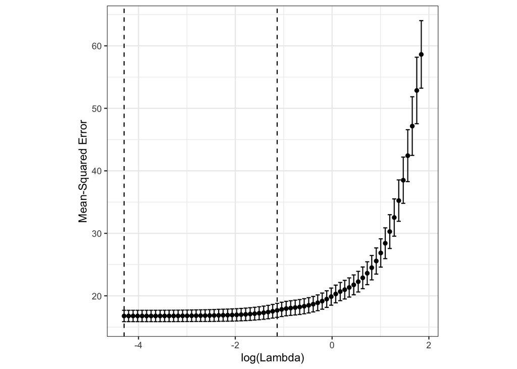

```r
bodyfat_x <- as.matrix(bodyfat[, 1:6]) # predictor variables
bodyfat_y <- bodyfat[, 7] # response variable

# use cross validation to pick the "best" (based on MSE) lambda
bodyfat_lasso_cv <- cv.glmnet(x = bodyfat_x,
                              y = bodyfat_y,
                              type.measure = "mse", #pmse
                              alpha = 1)  # 1 is code for "LASSO regression"

# plot (log) lambda vs MSE
autoplot(bodyfat_lasso_cv, label = FALSE) +
  theme_bw() +
  theme(aspect.ratio = 1)
```

```r
# lambda.min: value of lambda that gives minimum mean cross-validated error
bodyfat_lasso_cv$lambda.min
```

```
## [1] 0.01360079
```

```r
# lambda.1se: value of lambda within 1 standard error of the minimum
# cross-validated error
bodyfat_lasso_cv$lambda.1se
```

```
## [1] 0.3215893
```

```r
coef(bodyfat_lasso_cv, s = "lambda.min")
```

```
## 7 x 1 sparse Matrix of class "dgCMatrix"
##                      s1
## (Intercept) -1.38276732
## age          0.01915894
## weight      -0.01588789
## height      -0.36555931
## neck        -0.45224285
## chest       -0.10198093
## abdom        0.81608783
```

```r
coef(bodyfat_lasso_cv, s = "lambda.1se")
```

```
## 7 x 1 sparse Matrix of class "dgCMatrix"
##                      s1
## (Intercept) -9.14923265
## age          0.01413638
## weight       .
## height      -0.36234510
## neck        -0.12316579
## chest        .
## abdom        0.62309501
```

#### 14. Apply Elastic Net to this data set using the MSE metric. Output the coefficient values corresponding to the 1 standard error rule (do not output any plots).

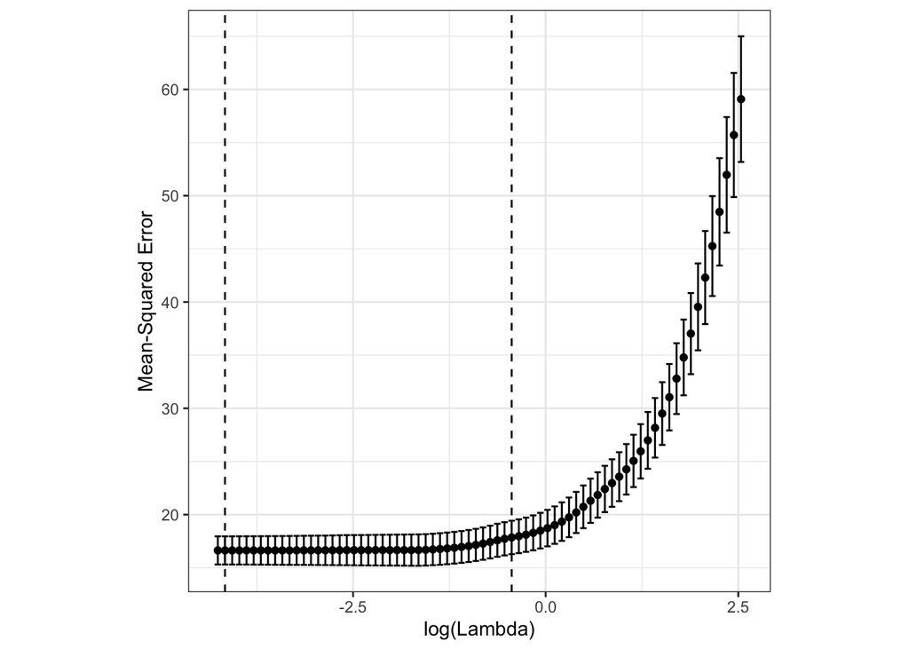

```r
bodyfat_x <- as.matrix(bodyfat[, 1:6]) # predictor variables
bodyfat_y <- bodyfat[, 7] # response variable

# use cross validation to pick the "best" (based on MSE) lambda
bodyfat_elastic_cv <- cv.glmnet(x = bodyfat_x,
                                y = bodyfat_y,
                                type.measure = "mse", #pmse
                                alpha = .5)  # .5 is code for "Elastic net regression"

# plot (log) lambda vs MSE
autoplot(bodyfat_elastic_cv, label = FALSE) +
  theme_bw() +
  theme(aspect.ratio = 1)
```

```r
# lambda.min: value of lambda that gives minimum mean cross-validated error
bodyfat_elastic_cv$lambda.min
```

```
## [1] 0.01556575
```

```r
# lambda.1se: value of lambda within 1 standard error of the minimum
# cross-validated error
bodyfat_elastic_cv$lambda.1se
```

```
## [1] 0.6431786
```

```r
coef(bodyfat_elastic_cv, s = "lambda.min")
```

```
## 7 x 1 sparse Matrix of class "dgCMatrix"
##                      s1
## (Intercept) -1.29423950
## age          0.01945238
## weight      -0.01616628
## height      -0.36542717
## neck        -0.45253664
## chest       -0.10439703
## abdom        0.81817801
```

```r
coef(bodyfat_elastic_cv, s = "lambda.1se")
```

```
## 7 x 1 sparse Matrix of class "dgCMatrix"
##                       s1
## (Intercept) -11.32886178
## age           0.02091262
## weight        .
## height       -0.34011121
## neck          .
## chest         .
## abdom         0.57584957
```

#### 15. Fill in the table below with “X”s (like the one at the end of the course notes: a row for each variable, a column for each variable selection method, an “X” in a cell means the variable was included for that variable selection method).

| Variable | Best Subset | Forward | Backward | Sequential Replacement | LASSO | Elastic Net |
| --- | --- | --- | --- | --- | --- | --- |
| age |  |  |  |  | X | X |
| weight | X | X |  | X |  |  |
| height |  |  | X |  | X | X |
| neck |  |  | X |  | X |  |
| chest |  |  |  |  |  |  |
| abdom | X | X | X | X | X | X |

#### 16. Now that you have seen the various results from the different methods, pick a subset of variables that you will include in the model. Which variables do you choose to include in the model? Why?

Based on the information gathered from different versions of the potential model, I would decide to go with weight and abdom in my model. I compared best subset with elastic net and decided to go with the simpler best subset model

#### 17. Create the multiple linear regression model with the variables you listed in the previous question (alternatively, you can call the best model using $BestModel). Print a summary of the results. Save the residuals from this model to the bodyfat dataframe.

```r
# Fitting model
bodyfat_lm <- lm(brozek ~ weight + abdom, data = bodyfat)
summary(bodyfat_lm)
```

```
##
## Call:
## lm(formula = brozek ~ weight + abdom, data = bodyfat)
##
## Residuals:
##      Min       1Q   Median       3Q      Max
## -10.0656  -2.9685  -0.1073   3.0258   9.9220
##
## Coefficients:
##              Estimate Std. Error t value Pr(>|t|)
## (Intercept) -42.87040    2.45735 -17.446  < 2e-16 ***
## weight       -0.12206    0.01966  -6.207 2.26e-09 ***
## abdom         0.90426    0.05221  17.321  < 2e-16 ***
## ---
## Signif. codes:  0 '***' 0.001 '**' 0.01 '*' 0.05 '.' 0.1 ' ' 1
##
## Residual standard error: 4.074 on 247 degrees of freedom
## Multiple R-squared:  0.7212, Adjusted R-squared:  0.7189
## F-statistic: 319.4 on 2 and 247 DF,  p-value: < 2.2e-16
```

```r
bodyfat$residuals = bodyfat_lm$residuals
bodyfat$fitted = bodyfat_lm$fitted.values
```

### Now that you have chosen a model, the next several questions ask you to check some of the model assumptions. For each assumption, (1) perform appropriate diagnostics to determine if the assumption is violated, and (2) explain whether or not you think the assumption is violated and why you think that. **Note: you can copy (then modify) a lot of your code from Homework 4 to answer these questions.**

#### 18. (L) The Xs vs Y are linear (use the scatterplot matrix and the partial regression plots)

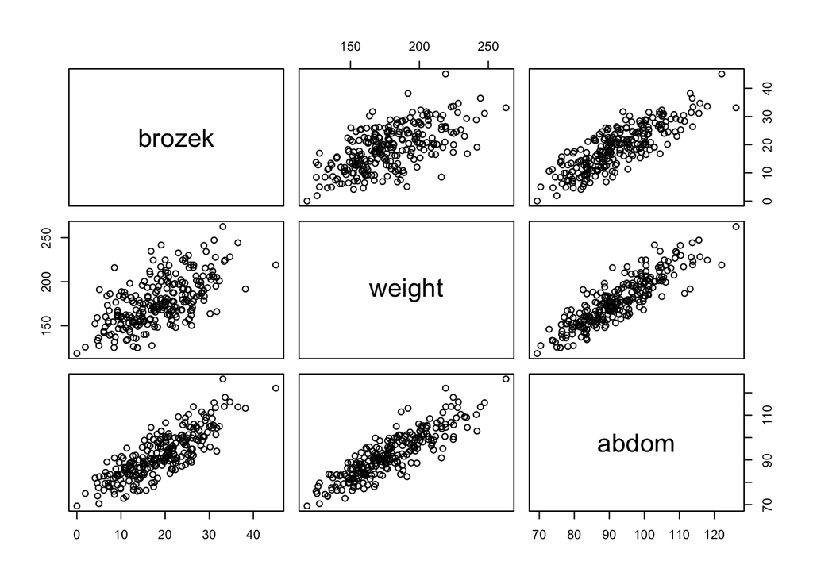

```r
# Correlation matrix
pairs(bodyfat %>% select(brozek, weight, abdom))
```

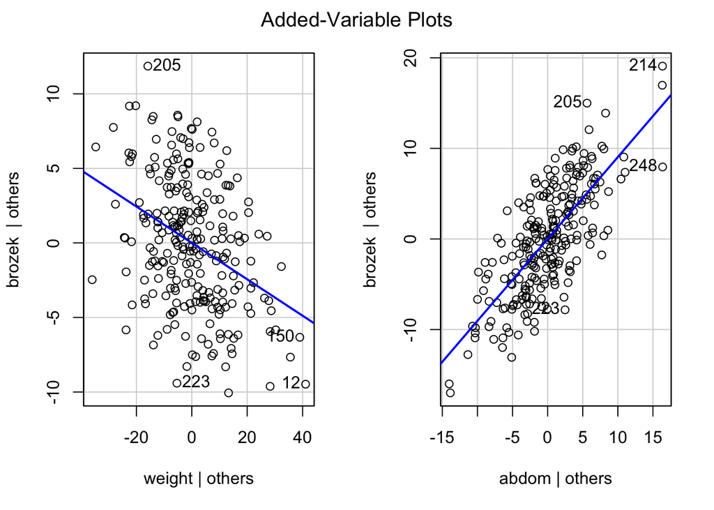

```r
# Partial regression plot
avPlots(bodyfat_lm)
```

I think that the model fits the linearity assumption. The scatterplots are clearly linear and the partial regression plots also show linearity.

#### 19. (N) The residuals are normally distributed and centered at zero (use the boxplot and normal probability plot)

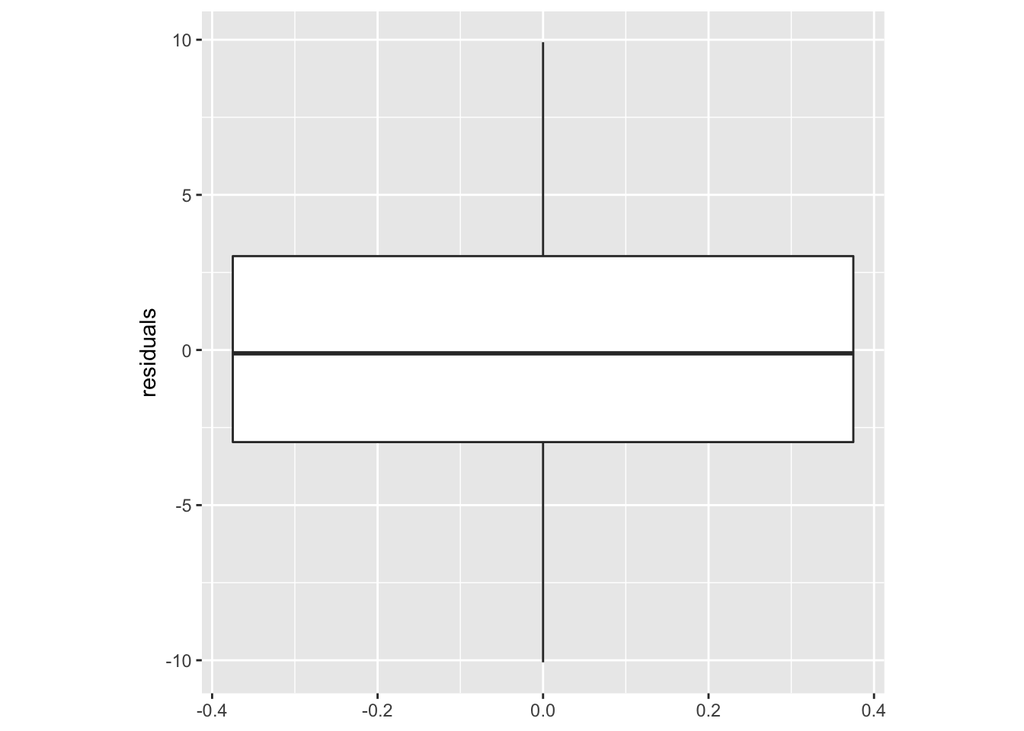

```r
# Boxplot
bodyfat_box <- ggplot(data = bodyfat) +
  geom_boxplot(aes(y = residuals)) +
  theme(aspect.ratio = 1)

bodyfat_box
```

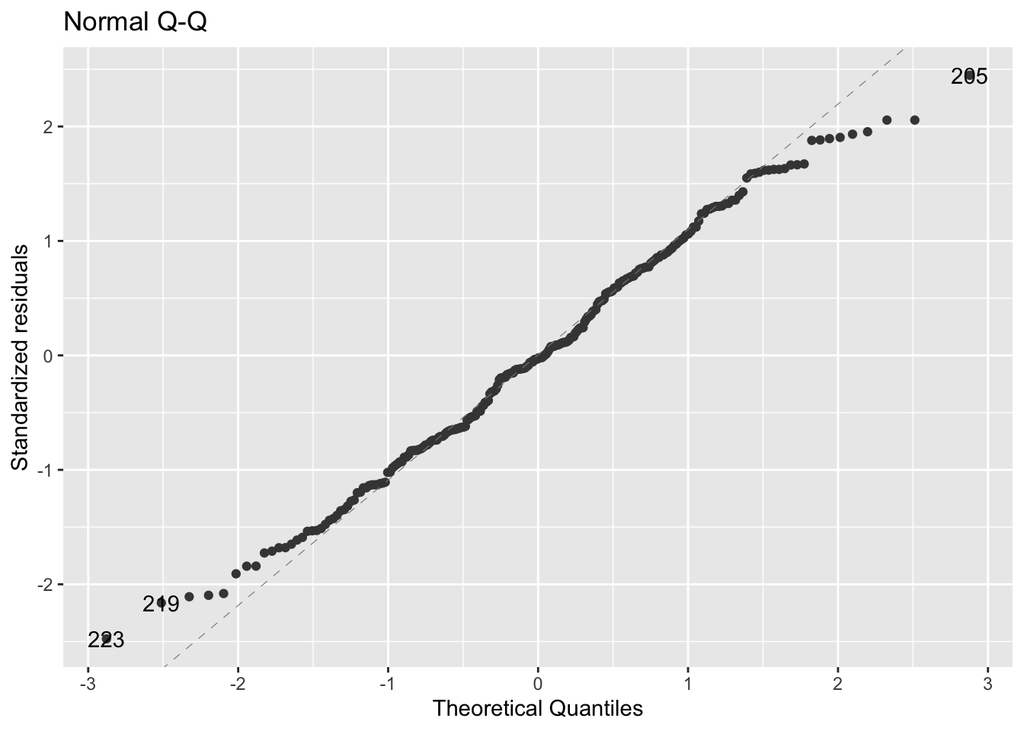

```r
# Normal probability plot
q_q <- autoplot(bodyfat_lm, which = 2, nrow = 1, ncol = 1)

q_q
```

#### 20. (E) The residuals have equal/constant variance across all values of X (use the residuals vs. fitted values plot)

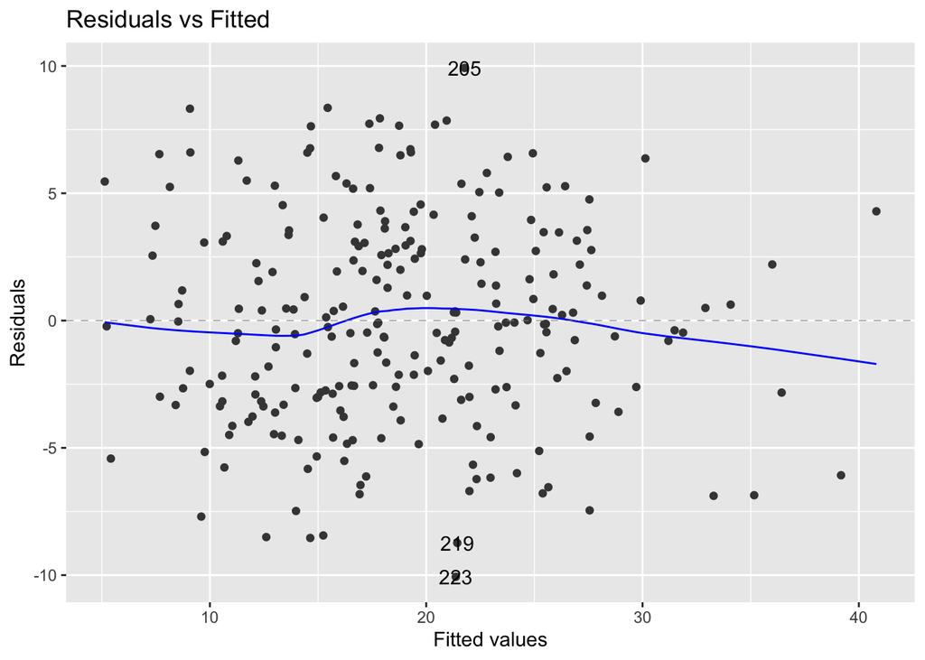

```r
# Residual Vs Fitted
res_vs_fitted <- autoplot(bodyfat_lm, which = 1, ncol = 1, nrow = 1)
res_vs_fitted
```

I don’t believe that the equal/constant variance assumption is met. I think that the vertical distance between points shrinks at higher fitted values.

#### 21. (A) The model describes all observations (i.e., there are no influential points) (use the DFBETAS and DFFITS)

```r
# DFBETAS

# Weight
bodyfat$dfbetas_weight <- as.vector(dfbetas(bodyfat_lm)[, 2])

dfbeta_weight <- ggplot(data = bodyfat) +
  geom_point(mapping = aes(x = as.numeric(rownames(bodyfat)),
                           y = abs(dfbetas_weight))) +
  ylab("Absolute Value of DFBETAS for Weight") +
  xlab("Observation Number") +
  geom_hline(mapping = aes(yintercept = 2 / sqrt(length(dfbetas_weight))),
             color = "red",
             linetype = "dashed") +
  theme(aspect.ratio = 1)

# Table view of observations detected by DFBETA
bodyfat %>%
  mutate(rowNum = row.names(bodyfat)) %>%  # save original row numbers
  filter(abs(dfbetas_weight) > 2 /
           sqrt(length(rownames(bodyfat)))) %>%  # select potential influential pts
  arrange(desc(abs(dfbetas_weight)))
```

```
##    age weight height neck chest abdom brozek residuals    fitted dfbetas_weight
## 1   72 186.75  66.00 38.9 111.1 111.5   28.3 -6.860256 35.160256      0.3084822
## 2   54 153.25  70.50 38.5  99.0  91.8   12.7 -8.735278 21.435278      0.2519421
## 3   27 216.00  76.00 39.4 103.6  90.9    8.5 -4.462145 12.962145     -0.2272179
## 4   39 234.75  74.50 42.8 109.5 104.5   16.8 -6.171503 22.971503     -0.2134025
## 5   44 166.00  65.50 39.1 100.6  93.9   31.7  9.922038 21.777962     -0.1903867
## 6   66 171.25  69.25 37.4 102.7  98.6   18.6 -6.787186 25.387186      0.1766543
## 7   67 163.75  67.75 38.4  97.7  95.8   30.2  6.429300 23.770700     -0.1750122
## 8   64 150.25  67.25 38.1  97.1  89.0   26.0  6.730480 19.269520     -0.1643402
## 9   51 219.00  64.00 41.2 119.8 122.1   45.1  4.290995 40.809005     -0.1527566
## 10  25 191.00  74.00 38.1 100.9  82.5    5.1 -3.317838  8.417838     -0.1452072
## 11  55 142.25  67.25 35.2  92.7  82.8    6.1 -8.539566 14.639566      0.1429127
## 12  70 134.25  67.00 34.9  89.2  83.6   11.5 -4.839461 16.339461      0.1388769
## 13  44 184.00  74.00 37.9 100.8  89.1    6.8 -8.440405 15.240405     -0.1347506
## 14  27 168.00  71.25 38.1  93.0  79.1   13.4  5.249269  8.150731      0.1302122
```

[output cut: 17 more lines]

```r
# Abdom
bodyfat$dfbetas_abdom <- as.vector(dfbetas(bodyfat_lm)[, 3])

dfbeta_abdom <- ggplot(data = bodyfat) +
  geom_point(mapping = aes(x = as.numeric(rownames(bodyfat)),
                           y = abs(dfbetas_abdom))) +
  ylab("Absolute Value of DFBETAS for Abdom") +
  xlab("Observation Number") +
  geom_hline(mapping = aes(yintercept = 2 / sqrt(length(dfbetas_abdom))),
             color = "red",
             linetype = "dashed") +
  theme(aspect.ratio = 1)

# Table view of observations detected by DFBETA
bodyfat %>%
  mutate(rowNum = row.names(bodyfat)) %>%  # save original row numbers
  filter(abs(dfbetas_abdom) > 2 /
           sqrt(length(rownames(bodyfat)))) %>%  # select potential influential pts
  arrange(desc(abs(dfbetas_abdom)))
```

```
##    age weight height neck chest abdom brozek residuals    fitted dfbetas_weight
## 1   72 186.75  66.00 38.9 111.1 111.5   28.3 -6.860256 35.160256     0.30848216
## 2   51 219.00  64.00 41.2 119.8 122.1   45.1  4.290995 40.809005    -0.15275659
## 3   54 153.25  70.50 38.5  99.0  91.8   12.7 -8.735278 21.435278     0.25194207
## 4   27 216.00  76.00 39.4 103.6  90.9    8.5 -4.462145 12.962145    -0.22721794
## 5   66 171.25  69.25 37.4 102.7  98.6   18.6 -6.787186 25.387186     0.17665432
## 6   44 166.00  65.50 39.1 100.6  93.9   31.7  9.922038 21.777962    -0.19038667
## 7   63 219.15  69.50 40.2 117.6 113.8   26.4 -6.885304 33.285304     0.07472266
## 8   67 163.75  67.75 38.4  97.7  95.8   30.2  6.429300 23.770700    -0.17501224
## 9   27 168.00  71.25 38.1  93.0  79.1   13.4  5.249269  8.150731     0.13021221
## 10  27 146.00  72.25 34.1  88.5  72.8   10.6  5.460803  5.139197     0.08687544
## 11  43 152.25  67.75 37.5  95.9  78.0   17.4  8.321507  9.078493     0.07323167
## 12  25 191.00  74.00 38.1 100.9  82.5    5.1 -3.317838  8.417838    -0.14520718
## 13  28 151.25  67.75 34.5  90.2  76.3   14.2  6.536696  7.663304     0.08078797
## 14  44 184.00  74.00 37.9 100.8  89.1    6.8 -8.440405 15.240405    -0.13475058
```

[output cut: 19 more lines]

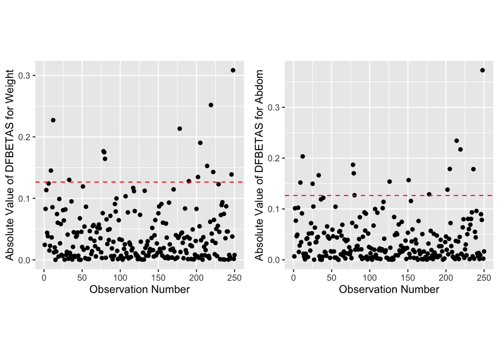

```r
ggarrange(dfbeta_weight, dfbeta_abdom, ncol = 2)
```

```r
# DFFITS
bodyfat$dffits <- dffits(bodyfat_lm)

dffits <- ggplot(data = bodyfat) +
  geom_point(mapping = aes(x = as.numeric(rownames(bodyfat)),
                           y = abs(dffits))) +
  ylab("Absolute Value of DFFITS for Brozek") +
  xlab("Observation Number") +
  geom_hline(mapping = aes(yintercept = 2 * sqrt(length(bodyfat_lm$coefficients) /
                                                   length(dffits))),
             color = "red",
             linetype = "dashed") +
  theme(aspect.ratio = 1)

bodyfat %>%
  mutate(rowNum = row.names(bodyfat)) %>%  # save original row numbers
  # select potential influential pts
  filter(abs(dffits) > 2 * sqrt(length(bodyfat_lm$coefficients) /
                                  length(dffits))) %>%
  arrange(desc(abs(dffits)))
```

```
##    age weight height neck chest abdom brozek residuals    fitted dfbetas_weight
## 1   72 186.75  66.00 38.9 111.1 111.5   28.3 -6.860256 35.160256     0.30848216
## 2   45 262.75  68.75 43.2 128.3 126.2   33.1 -6.076342 39.176342    -0.04490656
## 3   54 153.25  70.50 38.5  99.0  91.8   12.7 -8.735278 21.435278     0.25194207
## 4   42 244.25  76.00 41.8 115.2 113.7   36.5  6.368841 30.131159     0.12791153
## 5   63 219.15  69.50 40.2 117.6 113.8   26.4 -6.885304 33.285304     0.07472266
## 6   35 125.75  65.50 34.0  90.8  75.0    1.9 -7.700303  9.600303     0.11459402
## 7   51 219.00  64.00 41.2 119.8 122.1   45.1  4.290995 40.809005    -0.15275659
## 8   39 234.75  74.50 42.8 109.5 104.5   16.8 -6.171503 22.971503    -0.21340246
## 9   44 166.00  65.50 39.1 100.6  93.9   31.7  9.922038 21.777962    -0.19038667
## 10  27 216.00  76.00 39.4 103.6  90.9    8.5 -4.462145 12.962145    -0.22721794
## 11  43 152.25  67.75 37.5  95.9  78.0   17.4  8.321507  9.078493     0.07323167
## 12  55 142.25  67.25 35.2  92.7  82.8    6.1 -8.539566 14.639566     0.14291266
##    dfbetas_abdom     dffits rowNum
## 1  -0.3728772198 -0.3911079    248
## 2  -0.1219550414 -0.3495496     39
## 3  -0.2171278503 -0.2878225    219
## 4  -0.0074078683  0.2702443    190
## 5  -0.1783369333 -0.2680531    236
## 6   0.0008725763 -0.2673398    170
## 7   0.2342194383  0.2670759    214
## 8   0.1288210982 -0.2635631    178
## 9   0.1786676115  0.2481692    205
## 10  0.2033894144 -0.2386898     12
## 11 -0.1538276644  0.2386277    126
## 12 -0.0638226575 -0.2335167    222
```

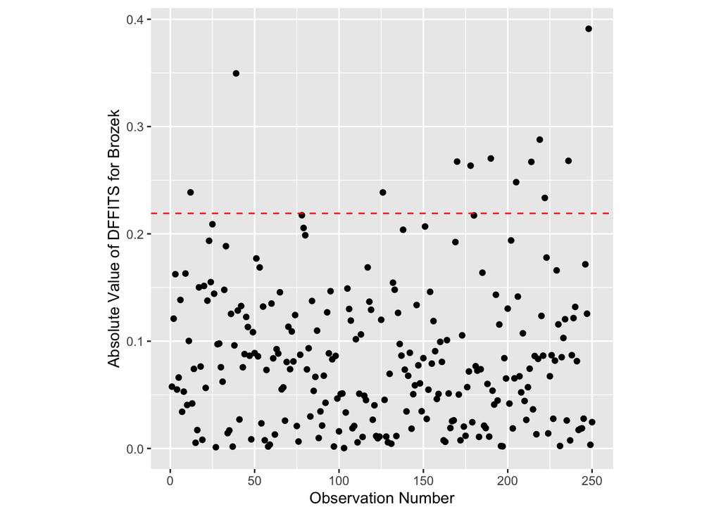

```r
dffits
```

I think that the observation at row 248 is a little bit iffy, but I would proceed under the assumption that the observations are met

#### 22. No multicollinearity (use the scatterplot matrix, correlation matrix, and variance inflation factors)

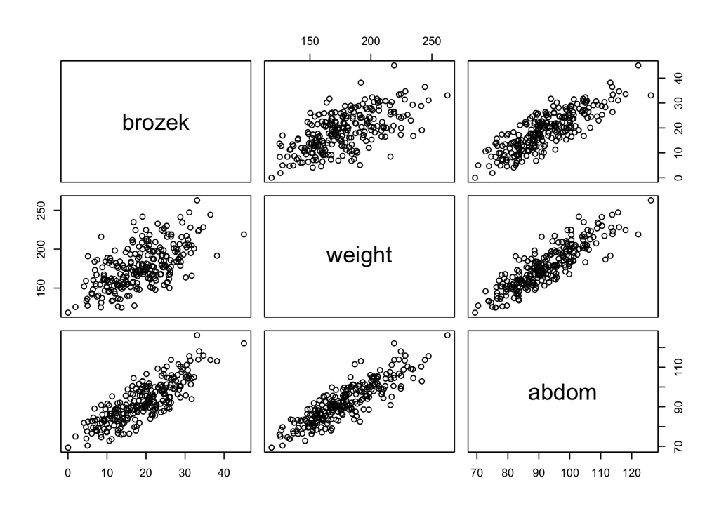

```r
# Scatterplot matrix
pairs(bodyfat %>% select(brozek, weight, abdom))
```

```r
# Correlation matrix
bodyfat %>%
  select(brozek, weight, abdom) %>%
  cor() %>%
  round(digits = 2)
```

```
##        brozek weight abdom
## brozek   1.00   0.62  0.82
## weight   0.62   1.00  0.87
## abdom    0.82   0.87  1.00
```

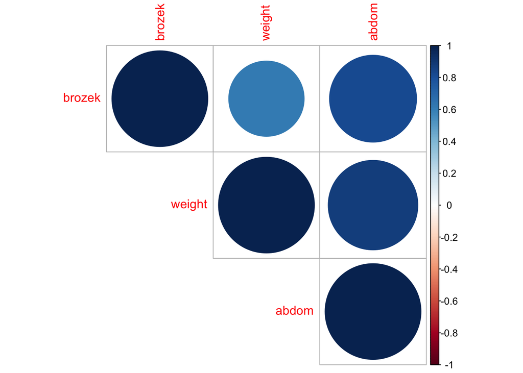

```r
# Plotting correlation matrix
bodyfat %>%
  select(brozek, weight, abdom) %>%
  cor() %>%
  corrplot(type = 'upper')
```

```r
# Variance inflation factors
vif(bodyfat_lm)
```

```
##   weight    abdom
## 4.242705 4.242705
```

```r
mean(vif(bodyfat_lm))
```

```
## [1] 4.242705
```

While there are still some indications of multicollinearity, the variance inflation factors are significantly lower than the full model. This level of multicollinearity is much more moderate and easier to manage.

#### 23. Given the results from your model assumption checking, what would you do next to continue this analysis?

Because there are some assumptions that aren’t met or are pretty suspect, I would start considering transforming the data in order to fit a better model. I’d also look at potentially exploring the elastic net model if I decided that the multicollinearity was going to be a big problem.

#### 24. Briefly summarize what you learned, personally, from this analysis about the statistics, model fitting process, etc.

I’ve learned that sometimes the steps that we take to fix models don’t always work perfectly. I assumed that using the best subsets selection method would fix multicollinearity in the data, but that wasn’t necessarily true. There is no single perfect model, we just have to pick the most useful one.

#### 25. Briefly summarize what you learned from this analysis *to a non-statistician*. Write a few sentences about (1) the purpose of this data set and analysis and (2) what you learned about this data set from your analysis. Write your response as if you were addressing a business manager (avoid using statistics jargon) and just provide the main take-aways.

Using this data, we would like to analyze the relationship between brozek (body fat percentage) and various body measurements such as age, weight, height, neck, chest, and abdom. While performing diagnostic measures on the data, it was determined that a simpler model could be used to predict brozek, using just weight and abdom measurements.